# SRout Assign 7

**1. Let X1, X2, . . . , Xn be n mutually independent random variables, each of which is uniformly distributed on the integers from 1 to k. Let Y denote the minimum of the Xi’s. Find the distribution of Y.**

**Answer**

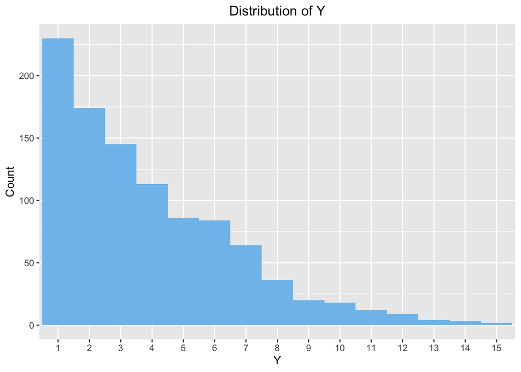

```r
library(ggplot2)
n <- 1000
k <- 20
Y <- c()
for (i in 1:n){
  Xn <- sample(1:k, 5, TRUE)
  Y <- c(Y, min(Xn))
}
ggplot(data.frame(table(Y)), aes(Y, Freq)) +
  geom_bar(stat = "identity", fill = "skyblue2", width = 1) +
  ylab("Count") +
  ggtitle("Distribution of Y") +
  theme(plot.title = element_text(hjust = 0.5))
```

**2. Your organization owns a copier (future lawyers, etc.) or MRI (future doctors). This machine has a manufacturer’s expected lifetime of 10 years. This means that we expect one failure every ten years. (Include the probability statements and R Code for each part.).**

**a. What is the probability that the machine will fail after 8 years?. Provide also the expected value and standard deviation. Model as a geometric. (Hint: the probability is equivalent to not failing during the first 8 years..)**

**Answer**

$$P(\text{failure after 8 years}) = 1 - \sum_{k=1}^{9} \frac{1}{10}\times\Big(\frac{9}{10}\Big)^{k-1}$$

```r
# by using regular
prob_succ <- 1/10
prob_fail <- 1 - prob_succ
n <- 8

expected_value_geom <- 1 / prob_succ
cat("Expected value:", expected_value_geom,'\n')
```

```
## Expected value: 10
```

```r
variance_geom <- (1 - prob_succ) / (prob_succ ^ 2)
sd_geom <- sqrt(variance_geom)
cat("Standard deviation:", sd_geom, '\n')
```

```
## Standard deviation: 9.486833
```

```r
#By hand P(X<=8) = P(X=0)+P(X=1)+....+P(X=7)+P(X=8)
i <- 1
Y <- c()
while (i <= 9 )
  {
  pg <-  (prob_succ) * (prob_fail ^ (i-1))
  Y <- c(Y, pg)
  i <- i + 1
}
cat("The probability that the machine will fail after 8 years is :", 1 - sum(Y), '\n')
```

```
## The probability that the machine will fail after 8 years is : 0.3874205
```

```r
# by using geometric distibution function, x > 8
pgeom(8, prob_succ, lower.tail = FALSE)
```

```
## [1] 0.3874205
```

**b. What is the probability that the machine will fail after 8 years? Provide also the expected value and standard deviation. Model as an exponential**

**Answer**
$$p(x >= k) = e^\frac{-k}{\lambda}$$
$$P(\text{failure after 8 years}) = e^\frac{-8}{10} = e^{-0.8}$$

```r
# by hand
prob_succ <- 1/10
expected_value_expo <- 1 / prob_succ
cat("Expected value:", expected_value_expo, '\n')
```

```
## Expected value: 10
```

```r
lamda <- 1 / expected_value_expo
variance_expo <- 1 / (lamda ^ 2)
sd_expo <- sqrt(variance_expo)
cat("Standard deviation:", sd_expo, '\n')
```

```
## Standard deviation: 10
```

```r
# P (x<=8) = e ^ (- lambda* x)
prob_expo <-  exp(- lamda * 8 )
cat("Probability that the machine will fail after 8 years:",  prob_expo, '\n')
```

```
## Probability that the machine will fail after 8 years: 0.449329
```

```r
# by using exponential distibution function, x > 8
pexp(8, 0.1, lower.tail = FALSE)
```

```
## [1] 0.449329
```

**c. What is the probability that the machine will fail after 8 years?. Provide also the expected value and standard deviation. Model as a binomial. (Hint: 0 success in 8 years)**

**Answer**

```r
# by hand
prob_succ <- 1/10
prob_fail <- 1 - prob_succ

expected_value_binom <- 8 * prob_succ
cat("Expected value:", expected_value_binom, '\n')
```

```
## Expected value: 0.8
```

```r
sd_binom <- sqrt(8 * prob_succ*(1 - prob_succ))
cat("Standard deviation:", sd_binom, '\n')
```

```
## Standard deviation: 0.8485281
```

```r
# P(x) = C(n,k) * (p ^ k) (1 - p ^ (n-k))
prob_binom <-  choose(8,0) * (prob_succ ^ 0) * (prob_fail ^ (8 - 0))
cat("Probability that the machine will fail after 8 years:",  prob_binom, '\n')
```

```
## Probability that the machine will fail after 8 years: 0.4304672
```

```r
# by using binomial distibution function, x > 8
pbinom(0,8, 0.1, lower.tail = TRUE)
```

```
## [1] 0.4304672
```

**d. What is the probability that the machine will fail after 8 years?. Provide also the expected value and standard deviation. Model as a Poisson.**

**Answer**
$$P(x) = \frac{\lambda^xe^{-\lambda}}{x!}$$

```r
# by hand
prob_succ <- 1/10
prob_fail <- 1 - prob_succ

expected_value_poiss <- 8 * prob_succ
cat("Expected value:", expected_value_poiss, '\n')
```

```
## Expected value: 0.8
```

```r
lamda <- expected_value_poiss
variance_poiss <- lamda

sd_poiss <- sqrt(variance_poiss)
cat("Standard deviation:", sd_poiss, '\n')
```

```
## Standard deviation: 0.8944272
```

```r
# P(x) = lambda ^ x * e ^ (- lambda) / n!
prob_poiss <-  ((lamda ^ 0) * exp(-lamda) ) / factorial(0)
cat("Probability that the machine will fail after 8 years:",  prob_poiss, '\n')
```

```
## Probability that the machine will fail after 8 years: 0.449329
```

```r
# by using Poisson function, x > 8
ppois(0, expected_value_poiss)
```

```
## [1] 0.449329
```